# Obesity levels based on dietary habits and physical condition in individuals from Colombia, Peru and Mexico

Regression task estimating the obesity levels based on dietary habits and physical activity

Nicola Rosca

December 7th, 2023

## Introduction

Nowadays, the population has access to a wide variety of food with various calories and nutrients. Everyone ranging from small children to elderly people can easily access food that might be detrimental for the health of the individual. With the increase of indoor activities, such as video games and television, the global population has found itself without the proper amount of physical activity. The combination between an unhealthy diet and the lack of physical activity is the reason more and more individuals are struggling with obesity. Therefore, it is necessary to be able to predict someone’s weight based on their diet and lifestyle, and to be able to offer advice on improvements. The model in this report aimed to do just that.

Palechor and de la Hoz Manotas (2021) have gathered data from Mexico, Peru and Colombia via a web survey. It contains 17 attributes and 2111 records.The attributes related with eating habits are: Frequent consumption of high caloric food (FAVC), Frequency of consumption of vegetables (FCVC), Number of main meals (NCP), Consumption of food between meals (CAEC), Consumption of water daily (CH20), and Consumption of alcohol (CALC). The columns related with the physical condition are: Calories consumption monitoring (SCC), Physical activity frequency (FAF), Time using technology devices (TUE), Transportation used (MTRANS), other variables obtained were: Gender, Age, Height and Weight. The authors also create the variable NObesity where they categorizes the body weight with values of: Insufficient Weight, Normal Weight, Overweight Level I, Overweight Level II, Obesity Type I, Obesity Type II and Obesity Type III. In this report, I used all the variables mentioned, besides NObeyesdad, because it categorizes the weight and therefore it is not useful to predict it.

The name of the dataset is “*Estimation of obesity levels based on eating habits and physical condition*”, found at https://archive.ics.uci.edu/dataset/544/estimation+of+obesity+levels+based+on+eating+habits+and+physical+condition.

This report looked at different types of models, linear with and without polynomial terms and k_Nearest Neighbor ( k = 1, 2, 3, 4) that can best predict body weight based on the above variables, using adjusted R2 and MAE as evidence of a successful model. The goal is to predict the weight as close as possible to the real number, looking at the adjusted R squared and the Mean Absolute Error values. Ideally, the best model will be able to predict the weight with no insignificant variables.

## Methodology

### Model Assessment

There are multiple ways to assess model success and how useful it can be in the real world. Most methods look at:

- the MSE (Mean Squared Error), which measure the magnitude of errors more accurately (Benli, 2023)
- the RMSE (Root Mean Square Error), which measures the magnitude of errors by squaring them and taking their root square (Benli, 2023)
- the MAE (Mean Absolute Error), which evaluates the differences between actual values and predicted values (Benli, 2023)
- the R2 that tells the performance of the model. R2 provides a baseline model to compare with other models, which none of the other metrics provide. R2 is ranges between 0 and 1. (Agrawal, 2023)
- the adjusted R2 that helps with the disadvantage of R2. According to Agrawal (2023), “R2 score is while adding new features in data the R2 score starts increasing or remains constant but it never decreases because It assumes that while adding more data variance of data increases”. Therefore, the adjusted R2 offers a more robust model assessment. The interpretation of an adjusted R2 is that the higher it is, the better the model fits and it penalizes the model for using variables that do not improve the prediction.
- the AIC helps deciding which independent variables need to be dropped in order to find the one that has the highest impact on weight gain and it is used to assess the fit of a model. It is “similar to the R-squared, but it has a different statistical basis”, according to Pius (2021). The aim is to have a very small AIC because “the value of the number itself has no inherent meaning, but it is used to compare different models of the same data”.

## Questions, variables, data types

```r
questions <- c(
"What is your gender?","What is your age?", "What is your height?", "What is your weight?", "Has a family member suffered or suffers from overweight?", "Do you eat high caloric food frequently?", "Do you usually eat vegetables in your meals?", "How many main meals do you have daily?", "Do you eat any food between meals?", "Do you smoke?", "How much water do you drink daily?", "Do you monitor the calories you eat daily?", "How often do you have physical activity?", "How often do you drink alcohol?", "How much time do you use technological devices such as cell phone, videogames, television, computer and others?", "Which transportation do you usually use?"
)

variables <- c(
"Gender", "Age", "Height", "Weight",  "family_history_with_overweight", "FAVC", "FCVC", "NCP", "CAEC", "SMOKE", "CH20", "SCC", "FAF", "CALC", "TUE", "MTRANS"
)

data_types <- c("Categorical", "Numerical", "Numerical", "Numerical", "Categorical", "Categorical", "Numerical", "Numerical", "Categorical", "Categorical", "Numerical", "Categorical", "Numerical", "Numerical", "Categorical", "Categorical")

questions_df <- data.frame(Question = questions, Variable = variables, Type=data_types)

knitr::kable(questions_df, caption = "List of Questions and Variables")
```

List of Questions and Variables

[output not shown]

## Exploratory data analysis and data splitting

```r
obesity$NObeyesdad <- NULL
View(obesity)
```

Several columns contain categorical values which will not render good enough visualization for in-depth analysis and linear models going forward, so I will be transforming them into factorial and then numerical values for ease of use.

#### Splitting the data

```r
obesity <- obesity %>%
  mutate_if(is.character, as.factor)
obesity2 <- obesity %>%
  mutate_if(is.factor, as.numeric)

as_tibble(lapply(obesity2, class)) %>%
  print(n=Inf, width=Inf)
```

```
## # A tibble: 1 × 16
##   Gender  Age     Height  Weight  family_history_with_overweight FAVC    FCVC
##   <chr>   <chr>   <chr>   <chr>   <chr>                          <chr>   <chr>
## 1 numeric numeric numeric numeric numeric                        numeric numeric
##   NCP     CAEC    SMOKE   CH2O    SCC     FAF     TUE     CALC    MTRANS
##   <chr>   <chr>   <chr>   <chr>   <chr>   <chr>   <chr>   <chr>   <chr>
## 1 numeric numeric numeric numeric numeric numeric numeric numeric numeric
```

```r
set.seed(16)

train <- obesity2 %>% slice_sample(prop = 0.34, replace = FALSE)
test  <- obesity2 %>% slice_sample(prop = 0.33, replace = FALSE)
validation <- obesity2 %>% slice_sample(prop = 0.33, replace = FALSE)

View(train)
View(test)
View(validation)
```

#### Number of records

```r
# Number of records
num_records <- nrow(train)
num_records
```

```
## [1] 717
```

#### Number of variables

```r
# Number of variables
num_variables <- ncol(train)
num_variables
```

```
## [1] 16
```

#### Name of variables

```r
# Names of input attributes
input_attribute <- names(train)
input_attribute
```

```
##  [1] "Gender"                         "Age"
##  [3] "Height"                         "Weight"
##  [5] "family_history_with_overweight" "FAVC"
##  [7] "FCVC"                           "NCP"
##  [9] "CAEC"                           "SMOKE"
## [11] "CH2O"                           "SCC"
## [13] "FAF"                            "TUE"
## [15] "CALC"                           "MTRANS"
```

#### Input data types

```r
# Types of input attributes
types <- sapply(train, class)
types
```

```
##                         Gender                            Age
##                      "numeric"                      "numeric"
##                         Height                         Weight
##                      "numeric"                      "numeric"
## family_history_with_overweight                           FAVC
##                      "numeric"                      "numeric"
##                           FCVC                            NCP
##                      "numeric"                      "numeric"
##                           CAEC                          SMOKE
##                      "numeric"                      "numeric"
##                           CH2O                            SCC
##                      "numeric"                      "numeric"
##                            FAF                            TUE
##                      "numeric"                      "numeric"
##                           CALC                         MTRANS
##                      "numeric"                      "numeric"
```

#### Percentage of missing values for each attribute

```r
missing_values <- colMeans(is.na(train)) * 100
missing_values
```

```
##                         Gender                            Age
##                              0                              0
##                         Height                         Weight
##                              0                              0
## family_history_with_overweight                           FAVC
##                              0                              0
##                           FCVC                            NCP
##                              0                              0
##                           CAEC                          SMOKE
##                              0                              0
##                           CH2O                            SCC
##                              0                              0
##                            FAF                            TUE
##                              0                              0
##                           CALC                         MTRANS
##                              0                              0
```

#### Output attribute

```r
target <- "Weight"
target
```

```
## [1] "Weight"
```

#### String representation

```r
str(train)
```

```
## tibble [717 × 16] (S3: tbl_df/tbl/data.frame)
##  $ Gender                        : num [1:717] 1 2 1 2 2 1 2 2 1 2 ...
##  $ Age                           : num [1:717] 40 18.1 21 21 19 ...
##  $ Height                        : num [1:717] 1.56 1.78 1.65 1.69 1.78 ...
##  $ Weight                        : num [1:717] 62.9 80.3 88.1 75 64 ...
##  $ family_history_with_overweight: num [1:717] 2 2 2 2 1 2 2 2 2 1 ...
##  $ FAVC                          : num [1:717] 2 2 2 2 2 2 2 2 2 2 ...
##  $ FCVC                          : num [1:717] 2.95 1.57 2.46 2 2 ...
##  $ NCP                           : num [1:717] 3 3 1 3 3 ...
##  $ CAEC                          : num [1:717] 4 4 4 4 4 4 4 1 4 4 ...
##  $ SMOKE                         : num [1:717] 1 1 1 1 1 1 1 1 1 1 ...
##  $ CH2O                          : num [1:717] 2.43 2 3 1.83 1 ...
##  $ SCC                           : num [1:717] 1 1 1 1 1 1 1 1 1 1 ...
##  $ FAF                           : num [1:717] 0.12 2.71 1.36 1 1 ...
##  $ TUE                           : num [1:717] 0.36 0 1 0 0 ...
##  $ CALC                          : num [1:717] 4 3 3 4 3 4 4 2 4 3 ...
##  $ MTRANS                        : num [1:717] 1 4 4 4 4 4 4 4 4 1 ...
```

#### Summary

```r
summary(train$Weight)
```

```
##    Min. 1st Qu.  Median    Mean 3rd Qu.    Max.
##   39.00   64.85   80.79   84.70  104.95  165.06
```

#### Occurances of Gender

```r
table(train$Gender)
```

```
##
##   1   2
## 368 349
```

## Visualising the dataframe

The following visualizations are used to highlight the split of data for various variables, but were also used in order to identify correlations between data, that can explored later on.

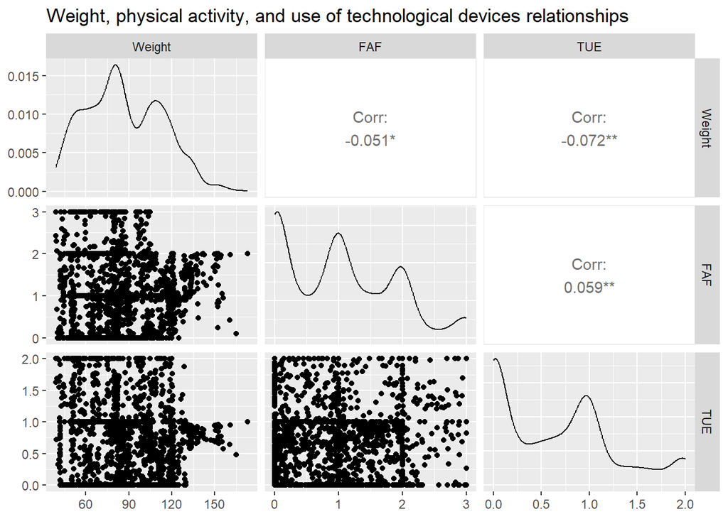

```r
pairs_plot <- ggpairs(obesity[, c("Weight", "FAF", "TUE")], upper_panel=NULL)
print(pairs_plot + ggtitle("Weight, physical activity, and use of technological devices relationships"))
```

Figure 1 - Weight, physical activity, and use of technological devices relationships

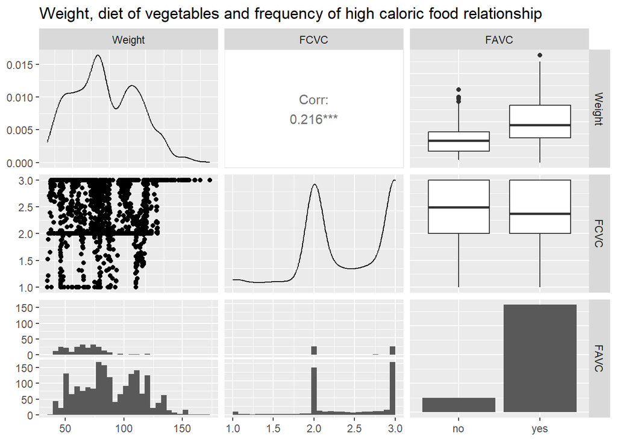

```r
pairs_plot2 <- ggpairs(obesity[, c("Weight", "FCVC", "FAVC")], upper_panel=NULL)
print(pairs_plot2 + ggtitle("Weight, diet of vegetables and frequency of high caloric food relationship "))
```

Figure 2 - Weight, diet of vegetables and frequency of high caloric food relationship

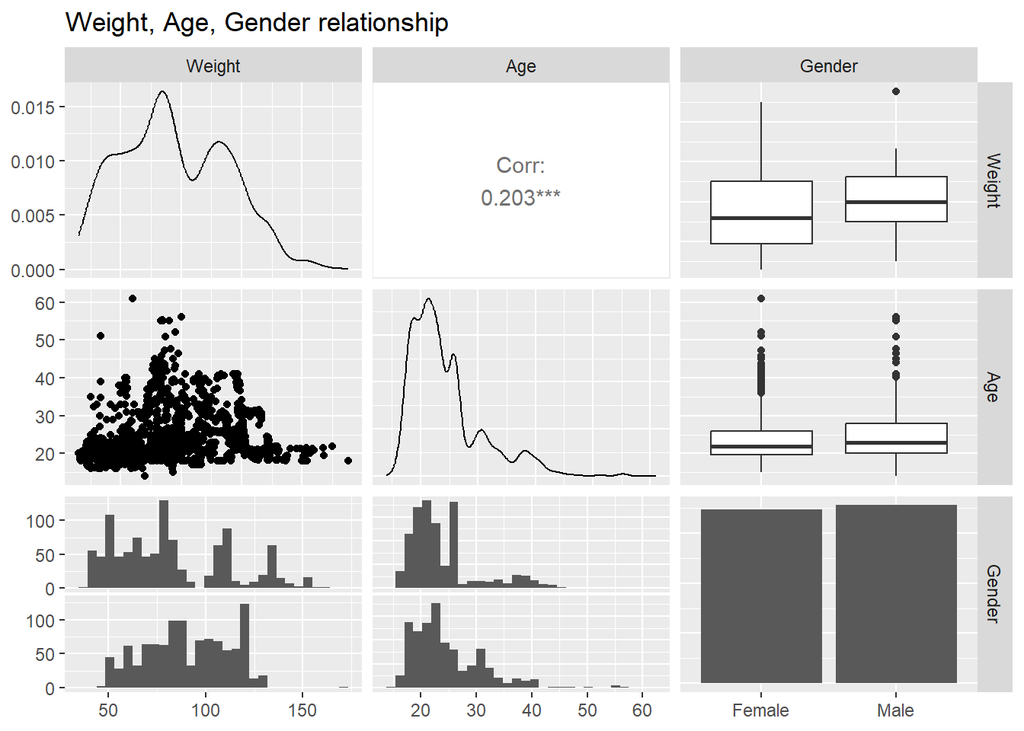

```r
pairs_plot3 <- ggpairs(obesity[, c("Weight", "Age", "Gender")], upper_panel=NULL)
print(pairs_plot3+ ggtitle("Weight, Age, Gender relationship "))
```

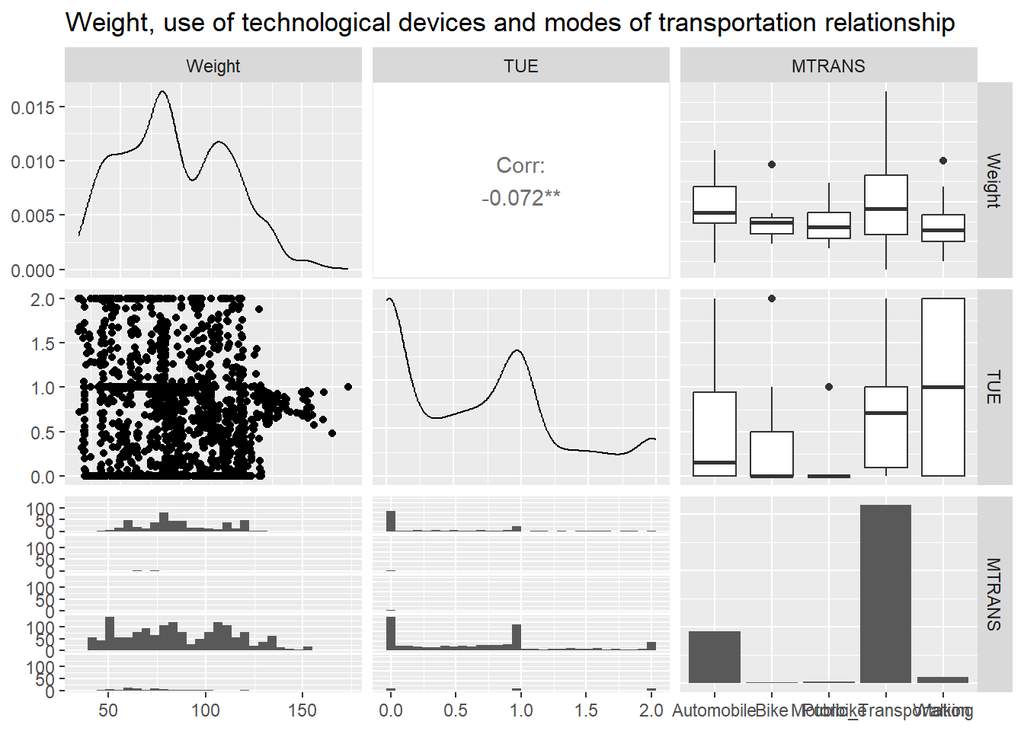

```r
pairs_plot4 <- ggpairs(obesity[, c("Weight", "TUE", "MTRANS")], , upper_panel=NULL)
print(pairs_plot4 + ggtitle("Weight, use of technological devices and modes of transportation relationship "))
```

Figure 4 - Weight, use of technological devices and modes of transportation relationship

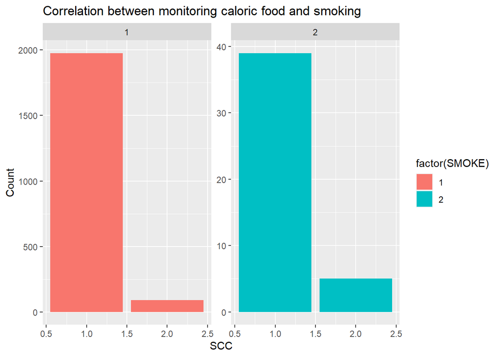

```r
plot_SMOKE_LEGEND <- ggplot(data = obesity2, aes(x = SCC, fill = factor(SMOKE))) +
  geom_bar(stat = "count", position = "stack") +
  facet_wrap(~SMOKE, scales = "free") +
  labs(title = "Correlation between monitoring caloric food and smoking", x = "SCC", y = "Count")

plot_SMOKE_LEGEND
```

Figure 5 - Correlation between monitoring caloric food and smoking

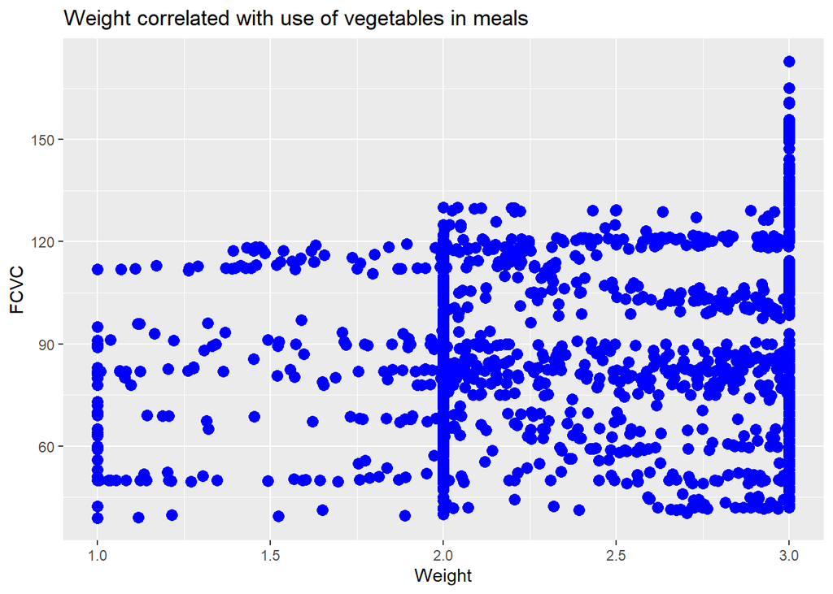

```r
ggplot(obesity2, aes(x = FCVC, y = Weight)) +
  geom_point(color = "blue", size = 3) +
  labs(title = "Weight correlated with use of vegetables in meals", x = "Weight", y = "FCVC")
```

Figure 6 - Weight correlated with use of vegetables in meals

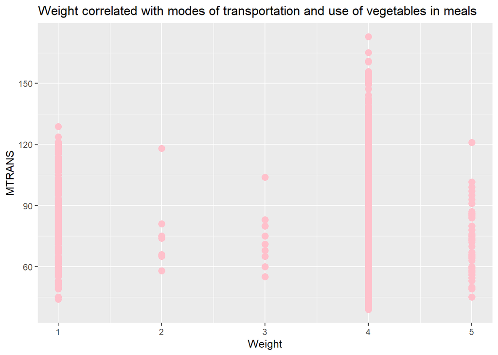

```r
ggplot(obesity2, aes(x = MTRANS, y = Weight)) +
  geom_point(color = "pink", size = 3) +
  labs(title = "Weight correlated with modes of transportation and use of vegetables in meals", x = "Weight", y = "MTRANS")
```

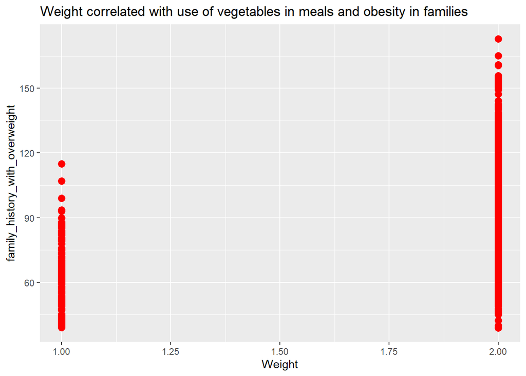

```r
ggplot(obesity2, aes(x = family_history_with_overweight, y = Weight)) +
  geom_point(color = "red", size = 3) +
  labs(title = "Weight correlated with use of vegetables in meals and obesity in families", x = "Weight", y = "family_history_with_overweight")
```

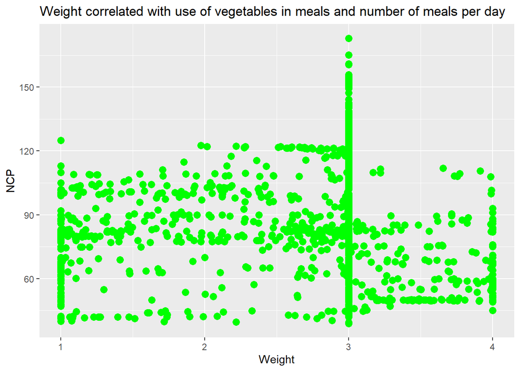

```r
ggplot(obesity2, aes(x = NCP, y = Weight )) +
  geom_point(color = "green", size = 3) +
  labs(title = "Weight correlated with use of vegetables in meals and number of meals per day", x = "Weight", y = "NCP")
```

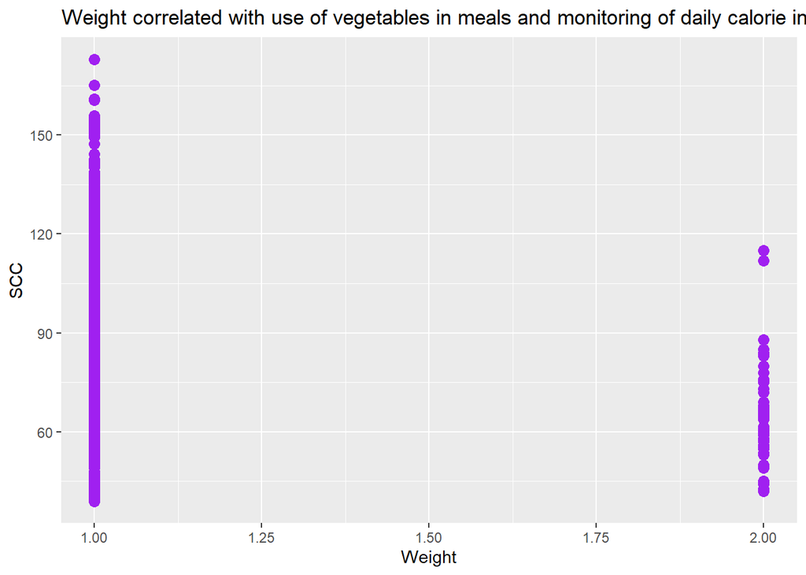

```r
ggplot(obesity2, aes(x = SCC, y = Weight)) +
  geom_point(color = "purple", size = 3) +
  labs(title = "Weight correlated with use of vegetables in meals and monitoring of daily calorie intake", x = "Weight", y = "SCC")
```

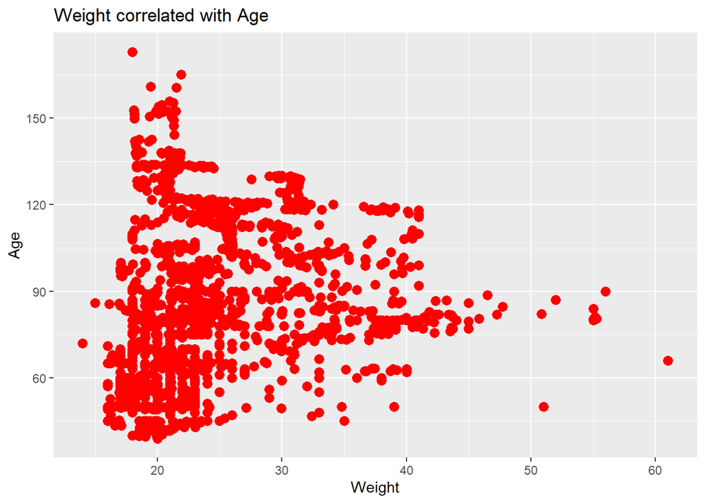

```r
weight_age <- ggplot(obesity, aes(x = Age, y = Weight)) +
  geom_point(color = "red", size = 3) +
  labs(title = "Weight correlated with Age", x = "Weight", y = "Age")
weight_age
```

Figure 11 - Weight correlated with Age

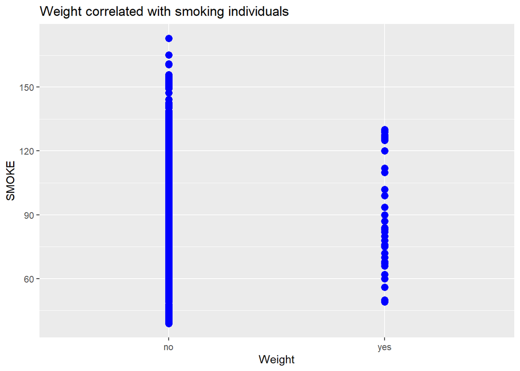

```r
weight_SMOKE <- ggplot(obesity, aes(x = SMOKE , y = Weight)) +
  geom_point(color = "blue", size = 3) +
  labs(title = "Weight correlated with smoking individuals", x = "Weight", y = "SMOKE")
weight_SMOKE
```

Figure 12 - Weight correlated with smoking individuals

## Linear models

### General model

In order to have a set starting point for the report, I will compute a linear model where the dependent variable “Weight” is twiddled with the rest of the variables. I will look at the correlation between them and try to implement the backward selection algorithm.

```r
general_lm <- lm(Weight ~ ., data = train)
summary_general_lm <- summary(general_lm)

model_summary <- as.data.frame(coefficients(summary_general_lm))

model_summary <- mutate_if(model_summary, is.numeric, round, 3)

View(model_summary)
```

The above linear model shows a Multiple R-squared of 0.62027, which means some of the independent variables have a direct correlation with the target column and implicitly, with weight gain that leads to obesity. Let us see which of these variables are the most impactful.

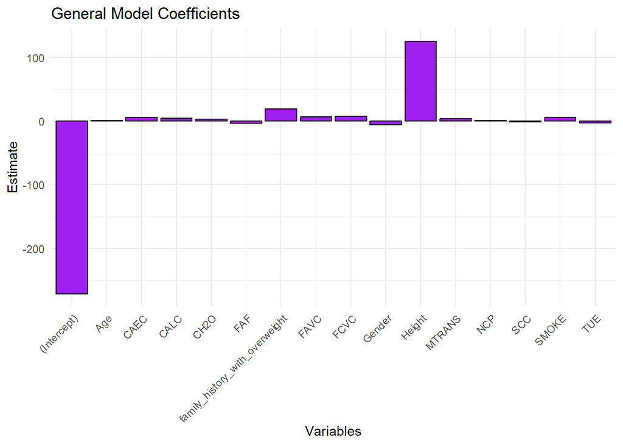

```r
ggplot(model_summary, aes(x = rownames(model_summary), y = Estimate)) +
  geom_bar(stat = "identity", fill = "purple", color = "black") +
  labs(title = "General Model Coefficients", x = "Variables", y = "Estimate") +
  theme_minimal() +
  theme(axis.text.x = element_text(angle = 45, hjust = 1))
```

At this point, it is necessary we look at the variables with the biggest impact on weight, and in this case we can see that the Height and family_history_with_overweight are relevant. However, I wondered if Height has a significant importance due to the fact that it auto correlates with the body weight. I noticed that the rest of the variables are concerned just with the diet and the physical activity, and height is the only one that refers to the individual’s body. I kept this in mind, whilst I computed the AIC criterion and performed variable selection.

## Variable selection

### Backward selection algorithm - AIC

The next step was to look at the Akaike Information Criterion or the AIC.

A reminder that general_lm is the model that had the Weight twiddled with all the variables, and that gave us an adjusted R squared of 0.62. I took the general_lm formula, calculated the AIC and then eliminated each variable with the highest AIC one by one to see how it affects the model’s adjusted R squared.

```r
formula(general_lm)
```

```
## Weight ~ Gender + Age + Height + family_history_with_overweight +
##     FAVC + FCVC + NCP + CAEC + SMOKE + CH2O + SCC + FAF + TUE +
##     CALC + MTRANS
```

```r
AIC<-drop1(general_lm)
View(AIC)
```

Using the generated AIC values, I aimed to compute linear models, extracting the variables with the highest AIC from each model, because I want fewer predictors, a high adjusted R2 and low overall AIC.

I started with Height and highlighted the adjusted R squared at the bottom of every model.

```r
M1<-lm(data=train, Weight ~ Age + family_history_with_overweight + FAVC + FCVC + CAEC + CH2O + FAF + TUE + CALC + MTRANS)
summary(M1)
```

```
##
## Call:
## lm(formula = Weight ~ Age + family_history_with_overweight +
##     FAVC + FCVC + CAEC + CH2O + FAF + TUE + CALC + MTRANS, data = train)
##
## Residuals:
##     Min      1Q  Median      3Q     Max
## -59.947 -13.321  -0.898  12.363  63.073
##
## Coefficients:
##                                Estimate Std. Error t value             Pr(>|t|)
## (Intercept)                    -91.0862     9.3001  -9.794 < 0.0000000000000002
## Age                              0.9286     0.1624   5.719      0.0000000158245
## family_history_with_overweight  24.7090     2.0025  12.339 < 0.0000000000000002
## FAVC                            12.2466     2.3150   5.290      0.0000001631538
## FCVC                             7.7070     1.3247   5.818      0.0000000090297
## CAEC                             6.5827     0.9784   6.728      0.0000000000356
## CH2O                             4.8400     1.1875   4.076      0.0000510379675
## FAF                              0.4219     0.8763   0.481                 0.63
## TUE                             -1.9560     1.2213  -1.602                 0.11
## CALC                             6.0794     1.3763   4.417      0.0000115608335
## MTRANS                           3.5751     0.7839   4.561      0.0000060085019
##
## (Intercept)                    ***
## Age                            ***
## family_history_with_overweight ***
## FAVC                           ***
## FCVC                           ***
## CAEC                           ***
## CH2O                           ***
## FAF
## TUE
## CALC                           ***
## MTRANS                         ***
## ---
## Signif. codes:  0 '***' 0.001 '**' 0.01 '*' 0.05 '.' 0.1 ' ' 1
##
## Residual standard error: 19.15 on 706 degrees of freedom
## Multiple R-squared:  0.4579, Adjusted R-squared:  0.4503
## F-statistic: 59.64 on 10 and 706 DF,  p-value: < 0.00000000000000022
```

```r
model_aic2<-lm(data=train, Weight ~ Age + FAVC + FCVC + CAEC + CH2O + FAF + TUE + CALC + MTRANS)
summary(model_aic2)
```

```
##
## Call:
## lm(formula = Weight ~ Age + FAVC + FCVC + CAEC + CH2O + FAF +
##     TUE + CALC + MTRANS, data = train)
##
## Residuals:
##     Min      1Q  Median      3Q     Max
## -61.717 -14.007  -0.959  13.441  65.502
##
## Coefficients:
##              Estimate Std. Error t value             Pr(>|t|)
## (Intercept) -74.80315   10.14303  -7.375    0.000000000000462 ***
## Age           1.22123    0.17698   6.900    0.000000000011551 ***
## FAVC         16.22250    2.52575   6.423    0.000000000245535 ***
## FCVC          8.89744    1.45564   6.112    0.000000001622081 ***
## CAEC          9.65588    1.04247   9.262 < 0.0000000000000002 ***
## CH2O          6.99547    1.29409   5.406    0.000000088362383 ***
## FAF          -0.01034    0.96475  -0.011              0.99145
## TUE          -1.01023    1.34300  -0.752              0.45217
## CALC          4.53501    1.51006   3.003              0.00277 **
## MTRANS        3.84081    0.86335   4.449    0.000010030458542 ***
## ---
## Signif. codes:  0 '***' 0.001 '**' 0.01 '*' 0.05 '.' 0.1 ' ' 1
##
## Residual standard error: 21.1 on 707 degrees of freedom
## Multiple R-squared:  0.341,  Adjusted R-squared:  0.3327
## F-statistic: 40.66 on 9 and 707 DF,  p-value: < 0.00000000000000022
```

```r
model_aic3<-lm(data=train, Weight ~ Age + FAVC + FCVC + CH2O + FAF + TUE + CALC + MTRANS + family_history_with_overweight)
summary(model_aic3)
```

```
##
## Call:
## lm(formula = Weight ~ Age + FAVC + FCVC + CH2O + FAF + TUE +
##     CALC + MTRANS + family_history_with_overweight, data = train)
##
## Residuals:
##     Min      1Q  Median      3Q     Max
## -60.165 -13.299  -0.065  12.736  64.134
##
## Coefficients:
##                                Estimate Std. Error t value             Pr(>|t|)
## (Intercept)                    -85.8262     9.5529  -8.984 < 0.0000000000000002
## Age                              1.0107     0.1669   6.055       0.000000002278
## FAVC                            14.7631     2.3550   6.269       0.000000000632
## FCVC                             7.3893     1.3647   5.415       0.000000084172
## CH2O                             5.2368     1.2226   4.284       0.000020942423
## FAF                              0.3653     0.9033   0.404                0.686
## TUE                             -1.4949     1.2570  -1.189                0.235
## CALC                             7.5762     1.4000   5.411       0.000000085687
## MTRANS                           3.6043     0.8080   4.461       0.000009509124
## family_history_with_overweight  28.1387     1.9962  14.096 < 0.0000000000000002
##
## (Intercept)                    ***
## Age                            ***
## FAVC                           ***
## FCVC                           ***
## CH2O                           ***
## FAF
## TUE
## CALC                           ***
## MTRANS                         ***
## family_history_with_overweight ***
## ---
## Signif. codes:  0 '***' 0.001 '**' 0.01 '*' 0.05 '.' 0.1 ' ' 1
##
## Residual standard error: 19.74 on 707 degrees of freedom
## Multiple R-squared:  0.4232, Adjusted R-squared:  0.4158
## F-statistic: 57.63 on 9 and 707 DF,  p-value: < 0.00000000000000022
```

```r
model_aic4<-lm(data=train, Weight ~ FAVC + FCVC + NCP + SMOKE + CH2O + SCC + FAF + TUE + CALC + MTRANS)
summary(model_aic4)
```

```
##
## Call:
## lm(formula = Weight ~ FAVC + FCVC + NCP + SMOKE + CH2O + SCC +
##     FAF + TUE + CALC + MTRANS, data = train)
##
## Residuals:
##     Min      1Q  Median      3Q     Max
## -53.793 -16.404   1.214  15.843  63.036
##
## Coefficients:
##             Estimate Std. Error t value          Pr(>|t|)
## (Intercept) -16.4932    11.9840  -1.376          0.169176
## FAVC         19.6761     2.6966   7.297 0.000000000000795 ***
## FCVC          9.8627     1.5611   6.318 0.000000000470050 ***
## NCP           3.0714     1.0995   2.793          0.005356 **
## SMOKE        18.1837     6.7095   2.710          0.006889 **
## CH2O          7.9105     1.3883   5.698 0.000000017783399 ***
## SCC         -17.5292     3.9327  -4.457 0.000009652553473 ***
## FAF          -1.8319     1.0332  -1.773          0.076641 .
## TUE          -3.6168     1.4123  -2.561          0.010645 *
## CALC          6.0364     1.6240   3.717          0.000218 ***
## MTRANS       -0.3901     0.7057  -0.553          0.580536
## ---
## Signif. codes:  0 '***' 0.001 '**' 0.01 '*' 0.05 '.' 0.1 ' ' 1
##
## Residual standard error: 22.73 on 706 degrees of freedom
## Multiple R-squared:  0.2365, Adjusted R-squared:  0.2257
## F-statistic: 21.87 on 10 and 706 DF,  p-value: < 0.00000000000000022
```

Adjusted R squared is 0.2257 after taking out Age

```r
model_aic5<-lm(data=train, Weight ~ FAVC + NCP + SMOKE + CH2O + SCC + FAF + TUE + CALC + MTRANS)
summary(model_aic5)
```

```
##
## Call:
## lm(formula = Weight ~ FAVC + NCP + SMOKE + CH2O + SCC + FAF +
##     TUE + CALC + MTRANS, data = train)
##
## Residuals:
##     Min      1Q  Median      3Q     Max
## -49.361 -16.995  -0.223  17.739  68.477
##
## Coefficients:
##             Estimate Std. Error t value        Pr(>|t|)
## (Intercept)   4.3563    11.8335   0.368         0.71288
## FAVC         18.9123     2.7670   6.835 0.0000000000177 ***
## NCP           3.0251     1.1293   2.679         0.00756 **
## SMOKE        17.2305     6.8900   2.501         0.01262 *
## CH2O          8.6922     1.4203   6.120 0.0000000015492 ***
## SCC         -17.5510     4.0395  -4.345 0.0000159788855 ***
## FAF          -1.5295     1.0601  -1.443         0.14951
## TUE          -4.3138     1.4462  -2.983         0.00295 **
## CALC          6.9279     1.6618   4.169 0.0000343943149 ***
## MTRANS       -0.1912     0.7241  -0.264         0.79186
## ---
## Signif. codes:  0 '***' 0.001 '**' 0.01 '*' 0.05 '.' 0.1 ' ' 1
##
## Residual standard error: 23.35 on 707 degrees of freedom
## Multiple R-squared:  0.1933, Adjusted R-squared:  0.1831
## F-statistic: 18.83 on 9 and 707 DF,  p-value: < 0.00000000000000022
```

Adjusted R squared is 0.1831 after taking out FCVC

```r
model_aic6<-lm(data=train, Weight ~ FAVC + NCP + SMOKE + CH2O + SCC + FAF + TUE + CALC)
summary(model_aic6)
```

```
##
## Call:
## lm(formula = Weight ~ FAVC + NCP + SMOKE + CH2O + SCC + FAF +
##     TUE + CALC, data = train)
##
## Residuals:
##    Min     1Q Median     3Q    Max
## -49.42 -17.09   0.01  17.63  68.36
##
## Coefficients:
##             Estimate Std. Error t value        Pr(>|t|)
## (Intercept)    3.852     11.670   0.330         0.74147
## FAVC          18.958      2.760   6.869 0.0000000000142 ***
## NCP            3.050      1.125   2.711         0.00687 **
## SMOKE         17.236      6.885   2.503         0.01253 *
## CH2O           8.692      1.419   6.124 0.0000000015119 ***
## SCC          -17.565      4.036  -4.352 0.0000154987026 ***
## FAF           -1.531      1.059  -1.445         0.14897
## TUE           -4.371      1.429  -3.059         0.00230 **
## CALC           6.860      1.641   4.181 0.0000326404786 ***
## ---
## Signif. codes:  0 '***' 0.001 '**' 0.01 '*' 0.05 '.' 0.1 ' ' 1
##
## Residual standard error: 23.33 on 708 degrees of freedom
## Multiple R-squared:  0.1933, Adjusted R-squared:  0.1841
## F-statistic:  21.2 on 8 and 708 DF,  p-value: < 0.00000000000000022
```

Adjusted R squared is 0.1841 after taking out MTRANS (unchanged from the above model)

```r
model_aic7<-lm(data=train, Weight ~ FAVC + NCP + SMOKE + CH2O + SCC + TUE + CALC)
summary(model_aic7)
```

```
##
## Call:
## lm(formula = Weight ~ FAVC + NCP + SMOKE + CH2O + SCC + TUE +
##     CALC, data = train)
##
## Residuals:
##     Min      1Q  Median      3Q     Max
## -51.958 -17.546  -0.007  18.248  69.772
##
## Coefficients:
##             Estimate Std. Error t value         Pr(>|t|)
## (Intercept)    3.019     11.665   0.259          0.79584
## FAVC          19.296      2.752   7.011 0.00000000000551 ***
## NCP            2.842      1.116   2.546          0.01112 *
## SMOKE         16.663      6.879   2.422          0.01568 *
## CH2O           8.334      1.399   5.959 0.00000000400082 ***
## SCC          -18.013      4.028  -4.472 0.00000901082281 ***
## TUE           -4.404      1.430  -3.080          0.00215 **
## CALC           7.138      1.631   4.377 0.00001381584847 ***
## ---
## Signif. codes:  0 '***' 0.001 '**' 0.01 '*' 0.05 '.' 0.1 ' ' 1
##
## Residual standard error: 23.35 on 709 degrees of freedom
## Multiple R-squared:  0.1909, Adjusted R-squared:  0.1829
## F-statistic: 23.89 on 7 and 709 DF,  p-value: < 0.00000000000000022
```

Adjusted R squared is 0.1829 after taking out FAF

```r
model_aic8<-lm(data=train, Weight ~ FAVC + SMOKE + NCP + CH2O + SCC + TUE)
summary(model_aic8)
```

```
##
## Call:
## lm(formula = Weight ~ FAVC + SMOKE + NCP + CH2O + SCC + TUE,
##     data = train)
##
## Residuals:
##     Min      1Q  Median      3Q     Max
## -50.245 -17.106  -0.793  17.295  72.003
##
## Coefficients:
##             Estimate Std. Error t value          Pr(>|t|)
## (Intercept)   24.186     10.751   2.250          0.024770 *
## FAVC          20.853      2.764   7.546 0.000000000000138 ***
## SMOKE         18.063      6.959   2.596          0.009636 **
## NCP            3.334      1.125   2.964          0.003137 **
## CH2O           8.195      1.416   5.787 0.000000010749967 ***
## SCC          -18.217      4.079  -4.467 0.000009247179841 ***
## TUE           -5.025      1.441  -3.487          0.000518 ***
## ---
## Signif. codes:  0 '***' 0.001 '**' 0.01 '*' 0.05 '.' 0.1 ' ' 1
##
## Residual standard error: 23.65 on 710 degrees of freedom
## Multiple R-squared:  0.169,  Adjusted R-squared:  0.162
## F-statistic: 24.07 on 6 and 710 DF,  p-value: < 0.00000000000000022
```

Adjusted R squared is 0.162 after taking out CALC

```r
model_aic9<-lm(data=train, Weight ~ NCP + SMOKE + CH2O + SCC + TUE)
summary(model_aic9)
```

```
##
## Call:
## lm(formula = Weight ~ NCP + SMOKE + CH2O + SCC + TUE, data = train)
##
## Residuals:
##     Min      1Q  Median      3Q     Max
## -50.693 -17.655  -1.772  17.909  74.199
##
## Coefficients:
##             Estimate Std. Error t value          Pr(>|t|)
## (Intercept)   69.145      9.294   7.440 0.000000000000291 ***
## NCP            3.636      1.168   3.114           0.00192 **
## SMOKE         16.163      7.223   2.238           0.02554 *
## CH2O           8.255      1.471   5.613 0.000000028531177 ***
## SCC          -23.066      4.183  -5.514 0.000000049053352 ***
## TUE           -4.502      1.495  -3.012           0.00269 **
## ---
## Signif. codes:  0 '***' 0.001 '**' 0.01 '*' 0.05 '.' 0.1 ' ' 1
##
## Residual standard error: 24.56 on 711 degrees of freedom
## Multiple R-squared:  0.1024, Adjusted R-squared:  0.09606
## F-statistic: 16.22 on 5 and 711 DF,  p-value: 0.000000000000003643
```

Adjusted R squared is 0.09606 after taking out FAVC - FAVC took the R squared down significantly

```r
model_aic10<-lm(data=train, Weight ~ NCP + SMOKE+ SCC + TUE)
summary(model_aic10)
```

```
##
## Call:
## lm(formula = Weight ~ NCP + SMOKE + SCC + TUE, data = train)
##
## Residuals:
##     Min      1Q  Median      3Q     Max
## -51.183 -18.763  -2.137  18.883  77.376
##
## Coefficients:
##             Estimate Std. Error t value             Pr(>|t|)
## (Intercept)   85.150      9.033   9.427 < 0.0000000000000002 ***
## NCP            3.781      1.192   3.172              0.00158 **
## SMOKE         16.382      7.376   2.221              0.02667 *
## SCC          -23.095      4.272  -5.407         0.0000000878 ***
## TUE           -4.380      1.526  -2.870              0.00423 **
## ---
## Signif. codes:  0 '***' 0.001 '**' 0.01 '*' 0.05 '.' 0.1 ' ' 1
##
## Residual standard error: 25.08 on 712 degrees of freedom
## Multiple R-squared:  0.0626, Adjusted R-squared:  0.05733
## F-statistic: 11.89 on 4 and 712 DF,  p-value: 0.000000002357
```

Adjusted R squared is 0.05733 after taking out CH20

```r
model_aic11<-lm(data=train, Weight ~ NCP + SMOKE+ SCC)
summary(model_aic11)
```

```
##
## Call:
## lm(formula = Weight ~ NCP + SMOKE + SCC, data = train)
##
## Residuals:
##    Min     1Q Median     3Q    Max
## -54.99 -19.37  -1.75  18.70  78.31
##
## Coefficients:
##             Estimate Std. Error t value             Pr(>|t|)
## (Intercept)   84.042      9.070   9.265 < 0.0000000000000002 ***
## NCP            3.477      1.193   2.914              0.00369 **
## SMOKE         14.763      7.392   1.997              0.04618 *
## SCC          -22.485      4.288  -5.244          0.000000208 ***
## ---
## Signif. codes:  0 '***' 0.001 '**' 0.01 '*' 0.05 '.' 0.1 ' ' 1
##
## Residual standard error: 25.21 on 713 degrees of freedom
## Multiple R-squared:  0.05176,    Adjusted R-squared:  0.04777
## F-statistic: 12.97 on 3 and 713 DF,  p-value: 0.00000002941
```

Adjusted R squared is 0.04777 after taking out TUE

```r
model_aic12<-lm(data=train, Weight ~ NCP+ SCC)
summary(model_aic12)
```

```
##
## Call:
## lm(formula = Weight ~ NCP + SCC, data = train)
##
## Residuals:
##     Min      1Q  Median      3Q     Max
## -47.928 -20.089  -1.928  18.782  78.130
##
## Coefficients:
##             Estimate Std. Error t value             Pr(>|t|)
## (Intercept)   98.161      5.695  17.236 < 0.0000000000000002 ***
## NCP            3.419      1.195   2.860              0.00436 **
## SCC          -21.491      4.268  -5.035          0.000000604 ***
## ---
## Signif. codes:  0 '***' 0.001 '**' 0.01 '*' 0.05 '.' 0.1 ' ' 1
##
## Residual standard error: 25.26 on 714 degrees of freedom
## Multiple R-squared:  0.04645,    Adjusted R-squared:  0.04378
## F-statistic: 17.39 on 2 and 714 DF,  p-value: 0.0000000422
```

Adjusted R squared is 0.04378 after taking out SMOKE

```r
model_aic13<-lm(data=train, Weight ~ SCC)
summary(model_aic13)
```

```
##
## Call:
## lm(formula = Weight ~ SCC, data = train)
##
## Residuals:
##     Min      1Q  Median      3Q     Max
## -46.838 -18.844  -3.315  19.156  79.219
##
## Coefficients:
##             Estimate Std. Error t value             Pr(>|t|)
## (Intercept)  107.833      4.606  23.414 < 0.0000000000000002 ***
## SCC          -21.994      4.286  -5.132           0.00000037 ***
## ---
## Signif. codes:  0 '***' 0.001 '**' 0.01 '*' 0.05 '.' 0.1 ' ' 1
##
## Residual standard error: 25.39 on 715 degrees of freedom
## Multiple R-squared:  0.03553,    Adjusted R-squared:  0.03418
## F-statistic: 26.34 on 1 and 715 DF,  p-value: 0.0000003699
```

Adjusted R squared is 0.03418 after taking out NCP

#### Results of AIC backward selection algorithm

I will be using the first model as my M1.

### P value variable selection

With the initial set of models computed based on the AIC criterion, I moved on to the p value selection, namely searching for the variables that had the highest p values. As mentioned before, they are useful to identify the relationships in the model that are statistically significant. Even though the backward selection algorithm was useful in understanding that height needs to be taken out in order to have a model that computes only non-body related variables, it is not enough to be able to predict the weight and I believe it can be improved.

Firstly, I looked at the p value of the individual variables, computed in the general_lm model.

```r
summary(general_lm) #initial linear model where all the variables are twiddled with the weight value
```

```
##
## Call:
## lm(formula = Weight ~ ., data = train)
##
## Residuals:
##     Min      1Q  Median      3Q     Max
## -43.102 -11.483   0.808  10.016  52.531
##
## Coefficients:
##                                 Estimate Std. Error t value
## (Intercept)                    -271.5495    16.8188 -16.146
## Gender                           -5.7731     1.7380  -3.322
## Age                               1.0362     0.1466   7.066
## Height                          125.6751    10.1020  12.441
## family_history_with_overweight   19.2009     1.8178  10.563
## FAVC                              6.9487     2.0900   3.325
## FCVC                              7.2453     1.2148   5.964
## NCP                               0.6014     0.8397   0.716
## CAEC                              6.2574     0.8778   7.128
## SMOKE                             6.3963     5.1044   1.253
## CH2O                              2.9471     1.0614   2.777
## SCC                              -0.9110     3.0218  -0.301
## FAF                              -3.2897     0.8212  -4.006
## TUE                              -2.9342     1.0926  -2.686
## CALC                              4.6034     1.2322   3.736
## MTRANS                            4.1224     0.7043   5.853
##                                            Pr(>|t|)
## (Intercept)                    < 0.0000000000000002 ***
## Gender                                     0.000941 ***
## Age                                0.00000000000386 ***
## Height                         < 0.0000000000000002 ***
## family_history_with_overweight < 0.0000000000000002 ***
## FAVC                                       0.000931 ***
## FCVC                               0.00000000389629 ***
## NCP                                        0.474064
## CAEC                               0.00000000000253 ***
## SMOKE                                      0.210590
## CH2O                                       0.005639 **
## SCC                                        0.763139
## FAF                                0.00006835314375 ***
## TUE                                        0.007412 **
## CALC                                       0.000202 ***
## MTRANS                             0.00000000740995 ***
## ---
## Signif. codes:  0 '***' 0.001 '**' 0.01 '*' 0.05 '.' 0.1 ' ' 1
##
## Residual standard error: 16.92 on 701 degrees of freedom
## Multiple R-squared:  0.5802, Adjusted R-squared:  0.5712
## F-statistic: 64.59 on 15 and 701 DF,  p-value: < 0.00000000000000022
```

```r
p_values <- summary(general_lm)$coefficients[, "Pr(>|t|)"]
View(p_values)
```

NCP, SMOKE and SCC were the variables with the biggest p value, so I will be dropping them from the next models.

```r
summary_p_valuess <- ols_step_all_possible(M1)
View(summary_p_valuess)
```

Using the ols_step_all_possible(M1) function, I was able to extract the exact correlation of variables that is able to predict the body weight as close as possible, judging by the 0.4555621 R2 and the adjusted R2 of 0.4508595. I kept this formula for the future linear models: Age + family_history_with_overweight + FAVC + FCVC + CAEC + CH2O + TUE + CALC + MTRANS.

I will be updating the train, test and validation set to only include these variables:

```r
selected_columns <- c("Weight", "Age", "family_history_with_overweight", "FAVC", "FCVC", "CAEC", "CH2O", "TUE", "CALC", "MTRANS")


set_size <- min(nrow(train), nrow(test), nrow(validation))


new_train <- train %>%
  select(selected_columns) %>%
  slice_sample(n = set_size, replace = FALSE)
new_test <- test %>%
  select(selected_columns) %>%
  slice_sample(n = set_size, replace = FALSE)


new_validation <- validation %>%
  select(selected_columns) %>%
  slice_sample(n = set_size, replace = FALSE)


View(new_train)
View(new_test)
View(new_validation)
```

## Linear models with polynomial terms

The difference between a linear model and a linear models with polynomial terms is that, the latter allows more flexibility to capture non-linear relationships between variables, and linear models cannot always capture the complexity of the relationship. Polynomial terms are useful in understanding the direction in which the data goes, in order to be able to do a better weight prediction. (Agrawal, 2023)

According to Agrawal (2023), “the degrees of freedom in a polynomial regression with degree ‘d’ are equal to the number of coefficients that need to be estimated minus one”. It is important to highlight that there are limitations with polynomial terms, such as over fitting the data by using high degrees.

The polynomial terms that I have modified are age, frequency of high caloric food and having vegetables in meals. The reason behind choosing those variables to work with is because in Figures 2, 6 and 11 I noticed a significant correlation between them and body weight.

### M2

```r
M2<-lm(data=new_train, Weight~poly(Age^5) + family_history_with_overweight + FAVC + FCVC + CAEC + CH2O + TUE + MTRANS + CALC )
summary(M2)
```

```
##
## Call:
## lm(formula = Weight ~ poly(Age^5) + family_history_with_overweight +
##     FAVC + FCVC + CAEC + CH2O + TUE + MTRANS + CALC, data = new_train)
##
## Residuals:
##     Min      1Q  Median      3Q     Max
## -50.970 -13.830   0.012  12.965  61.233
##
## Coefficients:
##                                Estimate Std. Error t value             Pr(>|t|)
## (Intercept)                    -65.9360     8.0985  -8.142  0.00000000000000184
## poly(Age^5)                     35.9926    23.1793   1.553             0.120934
## family_history_with_overweight  26.3051     2.0413  12.886 < 0.0000000000000002
## FAVC                            11.6305     2.3714   4.905  0.00000117061389657
## FCVC                             8.5768     1.3652   6.283  0.00000000059172847
## CAEC                             7.2025     1.0261   7.019  0.00000000000538062
## CH2O                             4.4669     1.2042   3.709             0.000225
## TUE                             -3.3831     1.2436  -2.720             0.006687
## MTRANS                           1.1361     0.7062   1.609             0.108112
## CALC                             6.5294     1.4114   4.626  0.00000445118045621
##
## (Intercept)                    ***
## poly(Age^5)
## family_history_with_overweight ***
## FAVC                           ***
## FCVC                           ***
## CAEC                           ***
## CH2O                           ***
## TUE                            **
## MTRANS
## CALC                           ***
## ---
## Signif. codes:  0 '***' 0.001 '**' 0.01 '*' 0.05 '.' 0.1 ' ' 1
##
## Residual standard error: 19.49 on 686 degrees of freedom
## Multiple R-squared:  0.4365, Adjusted R-squared:  0.4291
## F-statistic: 59.05 on 9 and 686 DF,  p-value: < 0.00000000000000022
```

### M3

```r
M3<-lm(data=new_train, Weight ~  Age +  family_history_with_overweight + poly(FAVC^2) +  FCVC + CAEC + CH2O + TUE + MTRANS + CALC)
summary(M3)
```

```
##
## Call:
## lm(formula = Weight ~ Age + family_history_with_overweight +
##     poly(FAVC^2) + FCVC + CAEC + CH2O + TUE + MTRANS + CALC,
##     data = new_train)
##
## Residuals:
##     Min      1Q  Median      3Q     Max
## -59.374 -13.483  -0.784  12.492  62.574
##
## Coefficients:
##                                Estimate Std. Error t value             Pr(>|t|)
## (Intercept)                    -68.0440     8.7707  -7.758   0.0000000000000313
## Age                              0.9051     0.1616   5.601   0.0000000307868006
## family_history_with_overweight  24.5423     2.0239  12.126 < 0.0000000000000002
## poly(FAVC^2)                   102.9157    20.0597   5.130   0.0000003766050182
## FCVC                             7.9624     1.3409   5.938   0.0000000045787658
## CAEC                             6.8445     1.0070   6.797   0.0000000000232941
## CH2O                             4.8073     1.1803   4.073   0.0000518128869359
## TUE                             -1.9376     1.2411  -1.561                0.119
## MTRANS                           3.4661     0.7909   4.382   0.0000135745927974
## CALC                             6.0989     1.3814   4.415   0.0000117325257029
##
## (Intercept)                    ***
## Age                            ***
## family_history_with_overweight ***
## poly(FAVC^2)                   ***
## FCVC                           ***
## CAEC                           ***
## CH2O                           ***
## TUE
## MTRANS                         ***
## CALC                           ***
## ---
## Signif. codes:  0 '***' 0.001 '**' 0.01 '*' 0.05 '.' 0.1 ' ' 1
##
## Residual standard error: 19.1 on 686 degrees of freedom
## Multiple R-squared:  0.4593, Adjusted R-squared:  0.4522
## F-statistic: 64.74 on 9 and 686 DF,  p-value: < 0.00000000000000022
```

### M4

```r
M4<-lm(data=new_train, Weight ~ Age +  family_history_with_overweight + poly(FCVC^9) +  FAVC + CAEC + CH2O + TUE + CALC + MTRANS)
summary(M4)
```

```
##
## Call:
## lm(formula = Weight ~ Age + family_history_with_overweight +
##     poly(FCVC^9) + FAVC + CAEC + CH2O + TUE + CALC + MTRANS,
##     data = new_train)
##
## Residuals:
##     Min      1Q  Median      3Q     Max
## -61.737 -13.260  -0.334  12.529  60.427
##
## Coefficients:
##                                Estimate Std. Error t value             Pr(>|t|)
## (Intercept)                    -70.7467     8.7914  -8.047  0.00000000000000373
## Age                              0.9237     0.1595   5.790  0.00000001072153591
## family_history_with_overweight  24.2559     2.0030  12.110 < 0.0000000000000002
## poly(FCVC^9)                   139.3803    19.4434   7.169  0.00000000000196540
## FAVC                            11.8870     2.2957   5.178  0.00000029496887826
## CAEC                             7.5285     1.0037   7.501  0.00000000000019681
## CH2O                             4.8459     1.1658   4.157  0.00003638021649922
## TUE                             -1.9604     1.2266  -1.598                 0.11
## CALC                             5.4966     1.3730   4.003  0.00006924548520916
## MTRANS                           3.2244     0.7845   4.110  0.00004429796162458
##
## (Intercept)                    ***
## Age                            ***
## family_history_with_overweight ***
## poly(FCVC^9)                   ***
## FAVC                           ***
## CAEC                           ***
## CH2O                           ***
## TUE
## CALC                           ***
## MTRANS                         ***
## ---
## Signif. codes:  0 '***' 0.001 '**' 0.01 '*' 0.05 '.' 0.1 ' ' 1
##
## Residual standard error: 18.89 on 686 degrees of freedom
## Multiple R-squared:  0.4711, Adjusted R-squared:  0.4641
## F-statistic: 67.89 on 9 and 686 DF,  p-value: < 0.00000000000000022
```

Interestingly enough, this model captured the non-linear relationship between weight and what presumably is eating too little vegetables with meals, computed to the power of 9, whilst the other variables remain constant.

## K Nearest Neighbour

### K = 1

```r
observed = new_validation$Weight

knn_1_predictions <- knn(train = new_train[, -4],
                 test = new_validation[, -4],
                 cl = new_train$Weight,
                 k = 1)
knn_1_predictions = as.numeric(knn_1_predictions)
knn_1_predictions
```

```
##   [1]  72 474 435 212 458 107 325 199 403 498 362 486 214   4 161 359 246 105
##  [19] 204 181 442  76  64  73 130 211 302 145 145 106 192 274  38 192 529  80
##  [37]  98  84 392 128 529 524 286  98 128 223   7  30 145 239 445 254 110 145
##  [55] 195 458 207  46 273 302 104 333 274 350 152  83 237 197 192 374 192 325
##  [73] 414  13  48 308  38 192 506  52  64 314 109 425 449  84 526  59 364 466
##  [91] 339 192  70 150 208 182 208 301 192 193 438 425 375  51 222  81 425 309
## [109]  86 111 128   9  38 192 527  26 500 367  75 372 526  21 311   9 172  96
## [127] 135 128 124  38 204 219  53 156 289 438  98 216 157  25 274 454 145  71
## [145] 104 274 211 507 236 410 232  12  38 256 107  57  42 240 108 326  84 292
## [163]  46  84  25 169 239 247  21  64 224 524 447  38 137 509 277 388 191 498
## [181] 334 119 145 384 391 514 482 422 305  84 223 438 390 274 278 321 192 128
## [199] 405 505  62  84 245 136  57  70 132 144 144 361  59  67 529 128 474  64
## [217] 170 101  49 308 175  84 217 198 520  84 109 281  84 425 111 454 497 234
## [235] 437 485 192 309 184  38  17 151 308 387   9 166  64  38 505 201 430  40
## [253]  38  84 100 419 176 510  52 217 170 185  84 145 473  63  75 145  64 415
```

[output cut: 24 more lines]

```r
mae(observed, knn_1_predictions)
```

```
## [1] 156.3213
```

```r
observed = new_validation$Weight

knn_1_predictions = as.numeric(knn_1_predictions)

knn1_mae = mae(observed, knn_1_predictions)
View(knn1_mae)

class(validation$Weight)
```

```
## [1] "numeric"
```

```r
class(knn_1_predictions)
```

```
## [1] "numeric"
```

### K = 2

```r
knn_2_predictions <- knn(train = new_train[, -ncol(new_train)],
                         test = new_validation[, -ncol(new_validation)],
                         cl = new_train$Weight,
                         k = 2)

knn_2_predictions
```

```
##   [1] 57.259124  120.996074 114.187096 82.283185  120.158049 71
##   [7] 102.003378 80.400306  110.824698 129.991623 103.771371 122.137917
##  [13] 83.986714  41.452385  77.550345  104.928643 81.978743  63.597633
##  [19] 80.993373  78.435904  117.298233 57.790381  55         57.275946
##  [25] 71         82.249831  97.842406  75         75         65.031879
##  [31] 80         90         50         80.273807  165.057269 59.313525
##  [37] 63.597633  60         110.10589  70         155.242672 150.37757
##  [43] 95.032177  63.597633  70         83         41.452385  49.026214
##  [49] 75         85         117.57457  88.119139  66.5       75
##  [55] 80         120        81.978743  50.869704  89.998729  97.911865
##  [61] 65         102.686908 90         104.808542 75.279605  60
##  [67] 84.849349  80.386078  80         105.800158 80         102.000122
##  [73] 111.950113 42.367615  51.216463  98.54302   50         78.435904
##  [79] 133.554686 51.437985  57         99.623778  66.401407  112.471118
##  [85] 118.134898 60         152.094362 52.514302  105.000706 120.589419
```

[output cut: 102 more lines]

```r
observed = new_validation$Weight

knn_2_predictions = as.numeric(knn_2_predictions)

knn2_mae = mae(observed, knn_2_predictions)
View(knn2_mae)
```

### K = 3

```r
observed = new_validation$Weight

knn_3_predictions <- knn(train = new_train[, -4],
                         test = new_validation[, -4],
                         cl = new_train$Weight,
                         k = 3)

knn_3_predictions
```

```
##   [1] 56         121.471077 114.133149 82         120        71
##   [7] 102.233445 81.978743  110.818757 129.349471 103.771371 122.137917
##  [13] 82.085549  41.535047  77.224574  104.928643 86         66.401407
##  [19] 84.722222  78         117.298233 58.19515   55         57.275946
##  [25] 72         82.403076  97.449743  75         75         62.877347
##  [31] 80         90         50         80         155.242672 59.313525
##  [37] 65         60         110.10589  70         165.057269 152.217135
##  [43] 94.094184  61         70         83         42         49.026214
##  [49] 75         85         119.050381 88.129437  68         75
##  [55] 80         120        81.978743  50.869704  89.667406  97.842406
##  [61] 65         103.026858 90         104.810024 75.410647  60
##  [67] 84.687554  79.437921  79.58958   105.025808 80         102.233445
##  [73] 111.919155 42.541794  52.331172  102.003378 50         80
##  [79] 133.843033 51.437985  57         99.623778  66.401407  112.395309
##  [85] 118.114184 60         152.217135 53.783977  105.000097 120.975489
```

[output cut: 102 more lines]

```r
knn_3_predictions = as.numeric(knn_3_predictions)

knn3_mae = mae(observed, knn_3_predictions)
View(knn3_mae)
```

### K = 4

```r
observed = new_validation$Weight

knn_4_predictions <- knn(train = new_train[, -4],
                         test = new_validation[, -4],
                         cl = new_train$Weight,
                         k = 4)

knn_4_predictions
```

```
##   [1] 56         120.980508 114.133149 81.650778  120        66.4
##   [7] 102.233445 80.491339  110.818757 129.232708 105        122.137917
##  [13] 82.46376   41.535047  77.601483  104.928643 80         65
##  [19] 84.722222  78         117.384745 57.790381  55         57.790381
##  [25] 72         82.403076  97.842406  75         75         65.031879
##  [31] 80         89.998729  50         80         165.057269 59.409018
##  [37] 63.597633  60         110.10589  70         153.959945 150.37757
##  [43] 95         60         70         82.283185  41.220175  49.026214
##  [49] 75.383716  85         118.424156 88.129437  66.5       75
##  [55] 80         120        77         50.631889  89.251639  97.911865
##  [61] 65         102.781971 90         104.810024 77.224574  59.605028
##  [67] 83.986714  79.437921  80         105.800158 80         102.003378
##  [73] 111.950113 42.367615  50.631889  102.003378 50         78.574786
##  [79] 133.952675 51.607091  56         99         66.401407  110.714711
##  [85] 119.201465 60         152.094362 52.514302  105.000097 120.589419
```

[output cut: 102 more lines]

```r
knn_4_predictions = as.numeric(knn_4_predictions)

knn4_mae = mae(observed, knn_4_predictions)
View(knn4_mae)
```

## Predictions and validations

### M1

```r
predictions_m1 <- predict(M1, newdata = test)


observed = test$Weight

predictions_m1 = as.numeric(predictions_m1)
predictions_m1
```

```
##   [1]  56.91688 103.47249  89.22848 106.72177  48.85596  72.56487  97.82962
##   [8]  74.21705  79.67737  58.69616  74.76841  87.08120  99.23772  85.30506
##  [15]  85.89737 103.38875  80.66729  97.11788  97.37831  92.90897 100.94946
##  [22]  71.86800  91.78352  64.69077 105.37647  82.74356  50.46542  84.58481
##  [29]  98.01263  84.74550  91.33129 108.17113  83.26039  39.58305 109.00427
##  [36]  57.67634  86.98332 106.65000  75.91647  84.70371  94.37699  83.78853
##  [43]  84.66691  92.33965  81.46315  74.64462  77.79435  61.58641  96.83946
##  [50]  87.03741  72.71478  91.74249  73.44844  84.01333  74.55188  73.28978
##  [57]  63.63869  85.64653  80.50800  43.90545  88.14706 107.46601 107.32742
##  [64] 103.58694  61.41755  63.96436 103.01505  89.38644 105.24115 100.95691
##  [71]  90.39975 103.21602 104.86430  43.88541  65.65763  70.99030  57.60793
##  [78]  89.70661  76.51924  80.67322 101.34180  99.87185  75.33063  92.45380
##  [85]  99.42413  81.13604 105.87800 108.20474  66.63841  56.06217 103.98775
##  [92]  40.49145  95.26729  85.17985  59.53816  73.67901  85.26237  98.46751
##  [99]  82.93634  94.02670  87.25112  87.46050 102.99270  92.75074  92.83777
```

[output cut: 85 more lines]

```r
mae(observed, predictions_m1)
```

```
## [1] 15.72723
```

MAE prediction of 15.72723

### M2

```r
predictions_m2 <- predict(M2, newdata = new_validation)


observed = new_validation$Weight

predictions_m2 = as.numeric(predictions_m2)
predictions_m2
```

```
##   [1]  63.06054 102.57400  97.07603  86.17310  96.77876  44.60464  88.71906
##   [8]  87.05762 106.27782  79.66522  82.79313  99.83275  74.30019  58.49099
##  [15]  92.33792 101.67186  55.12720  68.72851  92.89121  73.02500  87.86561
##  [22]  84.86477  50.84394  80.68857  78.69219  88.30494  87.27510  93.39341
##  [29]  62.53991  74.09196  83.71444  85.08254  38.86683  89.73550 103.25431
##  [36]  85.37307  73.27029  58.71948 101.69708  65.45000  85.72577 101.98973
##  [43]  84.18531  54.34724  77.11804  89.75152  67.85331  61.03596  55.74059
##  [50]  84.43860 100.47727  96.15905  72.07468  91.71630  80.29616  80.81277
##  [57]  93.18727  89.91738  88.48034  86.28918  76.22684  96.32939  93.59035
##  [64] 103.66472  92.16282  92.02629  95.34370  84.43574  93.99954  98.81897
##  [71]  86.16598  96.11407 107.17650  45.96035  67.85491  88.06458  85.72577
##  [78]  97.16858 103.40173  47.60314  42.02838  96.76918 108.06150  92.23569
##  [85]  96.28781  70.05451 102.62170  88.17095 101.52080  96.35273  89.23440
##  [92]  82.79053  97.59535  93.11898  91.33788  89.06410  79.71443  99.71845
##  [99]  92.56467  82.55625  92.89633  84.73464  96.08829  78.49110  80.82113
```

[output cut: 85 more lines]

```r
mae(observed, predictions_m2)
```

```
## [1] 16.51007
```

### M3

```r
predictions_m3 <- predict(M3, newdata = new_validation)


observed = new_validation$Weight

predictions_m3 = as.numeric(predictions_m3)
predictions_m3
```

```
##   [1]  60.67950 104.10091  98.65733  88.40418  97.99274  50.03321  91.46050
##   [8]  89.84955 108.13623  84.10528  86.74367 105.01608  74.96339  57.69860
##  [15]  95.99900 103.69397  62.82989  72.47970  96.83015  68.31142  90.00690
##  [22]  76.65784  49.79625  72.33924  77.73872  84.84671  89.52380  90.93220
##  [29]  67.18480  77.31561  84.02918  86.89320  38.99112  85.49914 101.81727
##  [36]  74.12893  73.08203  57.38634 102.93558  65.56617  82.30098  98.95919
##  [43]  84.85418  55.35434  72.52834  91.47127  66.40022  59.98427  57.75068
##  [50]  82.73113 103.01946  96.80281  72.07299  89.72780  78.58020  83.12008
##  [57]  99.44210  86.66329  89.16827  89.55287  75.14391  98.66034  90.79752
##  [64] 106.20665  95.10107  80.27764  96.47863  88.30712  99.26712 102.31920
##  [71]  87.10001  98.45517 108.88729  43.21596  64.95122  89.44631  82.30098
##  [78]  98.93606  99.34964  43.92346  43.26676  98.86408 105.45023  91.33067
##  [85]  99.74343  68.35099 100.01478  86.08992 100.17723  97.31192  95.79623
##  [92]  83.94450  96.99553  93.42154  91.24269  93.61444  81.74798 103.57415
##  [99]  96.87611  84.86464  97.24010  84.38981  96.36392  77.50532  79.47218
```

[output cut: 85 more lines]

```r
mae(observed, predictions_m3)
```

```
## [1] 15.92534
```

### M4

```r
predictions_m4 <- predict(M4, newdata = new_validation)


observed = new_validation$Weight

predictions_m4 = as.numeric(predictions_m4)
predictions_m4
```

```
##   [1]  59.34465 100.63347  96.01257  89.95174  99.52339  47.91309  94.08787
##   [8]  90.76329 110.37613  82.56844  90.38986 103.20606  78.33162  56.16723
##  [15]  95.34662 105.89553  65.60724  69.55931  95.96665  66.03055  92.90308
##  [22]  74.29306  46.94400  71.90134  77.43971  83.06758  90.83711  89.22604
##  [29]  69.55006  76.35024  82.91091  84.72899  43.74591  84.36633 103.95293
##  [36]  71.73282  69.77920  56.50448 105.13040  63.51113  82.97946 101.04596
##  [43]  83.75059  52.59910  69.35259  93.65328  63.60088  59.62666  57.58668
##  [50]  81.06318 100.10754  96.73144  72.72538  88.01570  84.48028  86.79649
##  [57]  99.31636  85.63885  89.07342  88.49777  72.09536 100.81741  90.23668
##  [64] 108.42656  94.42463  83.65860  93.15354  88.17782  97.36336 102.68557
##  [71]  90.21676 100.61096 111.13414  42.03551  63.47003  89.41705  82.97946
##  [78]  96.08797 101.43091  41.88912  44.31250  95.92916 107.61383  89.06437
##  [85]  97.69292  70.05983 102.11787  84.29649  97.13128  94.97992  94.53787
##  [92]  82.82921  93.37586  89.85091  89.60371  92.66872  87.67717 103.89091
##  [99]  96.24856  83.77100  93.76360  88.15143  93.95533  78.84498  83.13834
```

[output cut: 85 more lines]

```r
mae(observed, predictions_m4)
```

```
## [1] 15.59679
```

### M5

```r
observed = new_validation$Weight

knn_2_predictions = as.numeric(knn_2_predictions)
knn_2_predictions
```

```
##   [1]  72 474 435 212 461 130 325 198 401 498 344 485 230   6 161 357 207  98
##  [19] 204 181 442  74  64  73 130 211 302 145 145 106 192 274  38 196 529  79
##  [37]  98  84 392 128 528 523 288  98 128 223   6  30 145 239 444 257 110 145
##  [55] 192 458 207  44 273 303 105 332 274 352 148  84 237 197 192 374 192 324
##  [73] 418  12  48 308  38 181 506  50  71 314 109 425 449  84 525  58 365 466
##  [91] 339 192  64 153 208 170 212 301 192 192 434 425 375  54 210  79 425 313
## [109]  98 111 128   9  38 192 527  26 501 367  75 372 527  25 307   9 172 105
## [127] 135 128 124  38 204 228  44 158 290 438  99 216 154  25 265 452 149  71
## [145] 104 274 216 514 228 409 232  13  36 256 105  53  42 241 118 326  84 309
## [163]  41  84  25 168 234 247  25  64 228 524 448  38 137 509 277 387 191 498
## [181] 337 119 143 384 391 513 482 422 310  84 216 438 386 274 278 321 192 128
## [199] 407 503  62  84 237 136  53  64 136 144 144 368  58  63 528 128 473  64
## [217] 175 103  51 308 186  84 215 198 520  84 109 281  87 425 117 454 497 239
## [235] 437 485 192 313 184  38  14 146 325 388   9 170  64  38 503 201 430  41
## [253]  38  84 105 415 192 513  55 217 173 185  84 145 473  63  75 149  70 419
```

[output cut: 24 more lines]

```r
mae(observed, knn_2_predictions)
```

```
## [1] 156.0988
```

It is quite interesting to notice that the k-NN models have a much higher number of predicted units compared to the linear models, and that can be because linear models are better at finding the line between the features and the response. Additionally, linear models can capture global patterns in the data.

## Testing MB

I also tested it on a never seen before data set, the test set, to see how it performs.

```r
MB <- M4
test_MB <- predict(M4, newdata = new_test)


observed = new_test$Weight

test_MB = as.numeric(test_MB)
test_MB
```

```
##   [1]  97.57049 105.29733  99.06122  73.16036  90.76329 103.92890  43.23684
##   [8]  96.11669  74.97726 104.90931 101.94438  96.83146  97.10546 109.78975
##  [15] 108.62807  59.09980  41.88912  58.35180  86.94742  68.60036  41.14864
##  [22]  83.70091  95.20686  37.15912  70.83383 112.00187  94.40548  71.33298
##  [29]  99.83984  52.95397  63.25994  78.77704  98.90594  93.73491 110.87562
##  [36]  76.23430  88.14815 108.12816  88.76979  90.61601 102.73982  89.54182
##  [43]  98.67057  61.88655  62.00103  92.62263  49.51220  93.73020  73.02307
##  [50]  90.26856 107.84729  87.09848  94.15553  90.94927 101.58862  58.17195
##  [57]  76.42238  92.18076  86.30803  44.31250  76.55924  92.58437 104.23516
##  [64] 104.65514  89.98303 103.25502  95.60900  83.75059  81.58645  62.92469
##  [71]  86.41209  73.55076  95.02655  53.08620  65.58391  97.27137  42.00224
##  [78]  99.46614  84.68526 102.60352 103.16027  46.20296 103.78532  94.62308
##  [85]  94.52165  96.49460  82.63965  60.30140  99.59864  67.99608  97.07731
##  [92]  97.65137  75.77568  71.02520  87.18176  87.01789 110.04204 109.76270
##  [99] 100.53023  81.80605 103.45982  97.76613  59.28113  99.55425 100.58176
```

[output cut: 85 more lines]

```r
mae(observed, test_MB)
```

```
## [1] 15.44347
```

The MAE for the best model is 15.44347, which suggest the model is only 15 unites above or under the real weight.

## Conclusion

According to Manna & Jewkes (2014), childhood obesity has always brought adverse and long-lasting consequences for individuals and their families. The obesity issue has increased in the last three decades and the numbers continue to remain high. The authors highlighted that “almost 10 percent of infants and toddlers carry excess weight for their length, and slightly more than 20 percent of children between the ages of two and five already are overweight or obese”. There are several aspects of a person’s life that lead to obesity, not just their height. The dietary and physical activity data used in this report was collected from Colombia, Peru and Mexico, as a result of a web survey and it was collected in order to estimate the obesity levels using decision trees. (Manna & Jewkes, 2014)

The variables were selected using the Akaike Information Criterion (or the AIC), that was run on a general model, where all variables are included in the formula. Based on the AIC, I noticed that height had such a significant impact, that I dropped it in order to tailor the model solely on non-physical attributes. This resulted in understanding that height has one of the highest impact on weight, because it is a body attribute, so I removed it from future formulas.

Having a model that can predict weight based on diet and physical activity alone is useful especially in a world where child obesity is increasing, yet it is still non-intrusive. The variables considered by the authors of the De-La-Hoz-Correa et al (2019), cover most basis of the diet and physical activity, and I believe they can continue to be used for this purpose. For future work, I aim to tune the M4 model enough that it can bring the MAE to a lower value, ideally under 5.

## References

Agrawal, R. (2023a) Know the best evaluation metrics for your regression model!, Analytics Vidhya. Available at: https://www.analyticsvidhya.com/blog/2021/05/know-the-best-evaluation-metrics-for-your-regression-model/#:~:text=R2%20score%20is%20a%20metric,score%20is%20independent%20of%20context (Accessed: 12 December 2023).

Agrawal, R. (2023b) Master polynomial regression with easy-to-follow tutorials, Analytics Vidhya. Available at: https://www.analyticsvidhya.com/blog/2021/07/all-you-need-to-know-about-polynomial-regression/#:~:text=A%20polynomial%20regression%20model%20is,the%20complexity%20of%20the%20relationship. (Accessed: 12 December 2023).

Benli, C. (2023) Evaluating success in Regression Models, Medium. Available at: https://medium.com/@mcbenli80/evaluating-success-in-regression-models-eec59f24fef2 (Accessed: 12 December 2023).

De-La-Hoz-Correa, E. et al. (2019) ‘Obesity level estimation software based on decision trees’, Journal of Computer Science, 15(1), pp. 67–77. doi:10.3844/jcssp.2019.67.77.

Engineering Statistics (no date) NIST/SEMATECH e-Handbook of Statistical Methods. Available at: https://www.itl.nist.gov/div898/handbook/index.htm (Accessed: 11 December 2023).

Frost, J. (2023) How to interpret p-values and coefficients in regression analysis, Statistics By Jim. Available at: https://statisticsbyjim.com/regression/interpret-coefficients-p-values-regression/ (Accessed: 12 December 2023).

Kaplan, D.T. (no date) Statistical modeling: A fresh approach, Chapter 16 Models of Yes/No Variables. Available at: https://dtkaplan.github.io/SM2-bookdown/models-of-yesno-variables.html (Accessed: 11 December 2023).

Manna, S. and Jewkes, A.M. (2014) ‘Understanding early childhood obesity risks: An empirical study using fuzzy signatures’, 2014 IEEE International Conference on Fuzzy Systems (FUZZ-IEEE) [Preprint]. doi:10.1109/fuzz-ieee.2014.6891838.

Ozili, P.K. (2022) ‘The acceptable R-square in Empirical Modelling for Social Science Research’, SSRN Electronic Journal [Preprint]. doi:10.2139/ssrn.4128165.

Palechor, F.M. and Manotras, A. de la H. (2019) Dataset for estimation of obesity levels based on eating habits and physical condition in individuals from Colombia, Peru and Mexico, ScienceDirect. Available at: https://www.sciencedirect.com/science/article/pii/S2352340919306985?via%3Dihub (Accessed: 11 December 2023).

Pius, E.H. and R. (2021) R for Health Data Science, 7.3 Fitting more complex models. Available at: https://argoshare.is.ed.ac.uk/healthyr_book/fitting-more-complex-models.html (Accessed: 12 December 2023).

Science, R. statistics for P. (2023) Choose model variables by AIC in a stepwise algorithm with the mass package in R, R Functions and Packages for Political Science Analysis. Available at: https://rforpoliticalscience.com/2020/10/23/choose-model-variables-by-aic-in-a-stepwise-algorithm-with-the-mass-package-in-r/ (Accessed: 11 December 2023).

Shekhar, P. (no date) How to apply linear regression in R, DataScience+. Available at: https://datascienceplus.com/how-to-apply-linear-regression-in-r/ (Accessed: 11 December 2023).